# Combined analysis

We are going to combine the samples that were run in February and the samples that were run in April to have more samples to increase our power to find differences between the samples.

```r
> load("april.RData")
> load("february.RData")
> library(DESeq2)
> library(ggplot2)
> library(pheatmap)
> aprcounts = counts(aprdds, normalized = FALSE)
> aprsummary = colData(aprdds)
> febcounts = counts(febdds, normalized = FALSE)
> febsummary = colData(febdds)
```

The sample data is coded a little bit different for both runs, so we will have to normalize them so they are the same. We will first drop everything except the metadata from the summary dataframes.

```r
> febsum = febsummary[, c("samplename", "fraction", "treatment", "group", "phenotype")]
> aprsum = aprsummary[, c("Name", "condition", "treatment", "patient")]
```

Now we need to recode some of the columns. We’ll add a ‘phenotype’ column to the April data.

```r
> aprsum$phenotype = ifelse(aprsum$condition == "HC", "noMS", "MS")
```

We’ll recode the treatment factors to be `L` for `LPS` and `LI` for `LPS+IL27` and `U` for untreated to avoid using a plus. We’ll also rename the `patient` column to `group` for the April samples and add a `a` or `f` prefix to make the groups unique across months. Finally we add a column for which month the sequencing was done.

```r
> aprsum$treat = ifelse(aprsum$treatment == "LPS", "L", "LI")
> febsum$treat = ifelse(febsum$treatment == "LPS", "L", ifelse(febsum$treatment ==
+     "natural", "U", "LI"))
> aprsum$group = aprsum$patient
> febmeta = febsum[, c("group", "treat", "phenotype")]
> aprmeta = aprsum[, c("group", "treat", "phenotype")]
> febmeta$month = "feb"
> aprmeta$month = "apr"
> febmeta$group = paste0("f", febmeta$group)
> aprmeta$group = paste0("a", aprmeta$group)
```

```r
> library(dplyr)
> melted = rbind(reshape2::melt(aprcounts), reshape2::melt(febcounts))
> colnames(melted) = c("gene", "sample", "count")
> combined = melted %>% tidyr::spread(sample, count) %>% as.data.frame()
> rownames(combined) = combined$gene
> combined$gene = NULL
> combined[is.na(combined)] = 0
> counts = combined
> metadata = rbind(febmeta, aprmeta)
> metadata$group = as.factor(metadata$group)
> metadata$treat = relevel(as.factor(metadata$treat), ref = "U")
> metadata$phenotype = relevel(as.factor(metadata$phenotype), ref = "noMS")
> metadata$phenotreat = relevel(as.factor(paste(metadata$phenotype, metadata$treat,
+     sep = "_")), ref = "noMS_U")
> metadata$sample = rownames(metadata)
> counts = counts[, rownames(metadata)]
```

And pull in the gene symbols from biomaRt.

```r
> mart = biomaRt::useMart(biomart = "ensembl", dataset = "hsapiens_gene_ensembl")
> symbols <- biomaRt::getBM(attributes = c("ensembl_gene_id", "external_gene_name",
+     "hgnc_symbol"), mart = mart)
```

And we’re almost good to go.

# Data cleaning

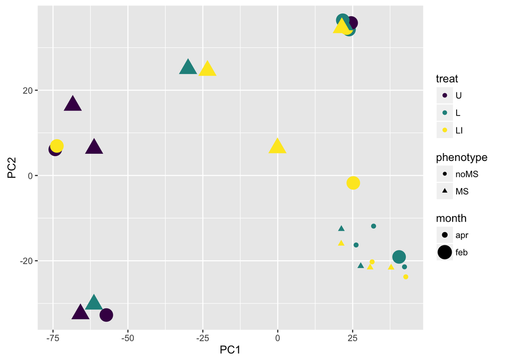

```r
> ddspca = DESeqDataSetFromMatrix(countData = counts, colData = metadata, design = ~treat +
+     phenotype + phenotype:treat)
> vst = varianceStabilizingTransformation(ddspca)
> pca_loadings = function(object, ntop = 500) {
+     rv <- matrixStats::rowVars(assay(object))
+     select <- order(rv, decreasing = TRUE)[seq_len(min(ntop, length(rv)))]
+     pca <- prcomp(t(assay(object)[select, ]))
+     percentVar <- pca$sdev^2/sum(pca$sdev^2)
+     names(percentVar) = colnames(pca$x)
+     pca$percentVar = percentVar
+     return(pca)
+ }
> pc = pca_loadings(vst)
> comps = data.frame(pc$x)
> comps$Name = rownames(comps)
> library(dplyr)
> comps = comps %>% left_join(as.data.frame(metadata), by = c(Name = "sample"))
> colorby = "phenotreat"
> pca_plot = function(comps, nc1, nc2, colorby) {
+     c1str = paste0("PC", nc1)
+     c2str = paste0("PC", nc2)
+     ggplot(comps, aes_string(c1str, c2str, color = colorby)) + geom_point() +
+         theme_bw() + xlab(paste0(c1str, ": ", round(pc$percentVar[nc1] * 100),
+         "% variance")) + ylab(paste0(c2str, ": ", round(pc$percentVar[nc2] *
+         100), "% variance"))
+ }
> library(viridis)
> ggplot(comps, aes(PC1, PC2, color = treat, shape = phenotype, size = month)) +
+     geom_point() + scale_color_viridis(discrete = TRUE)
```

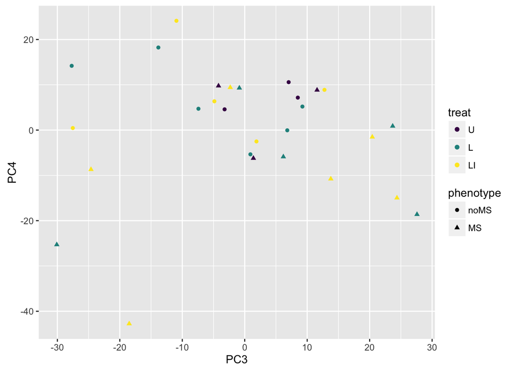

```r
> ggplot(comps, aes(PC3, PC4, color = treat, shape = phenotype)) + geom_point() +
+     scale_color_viridis(discrete = TRUE)
```

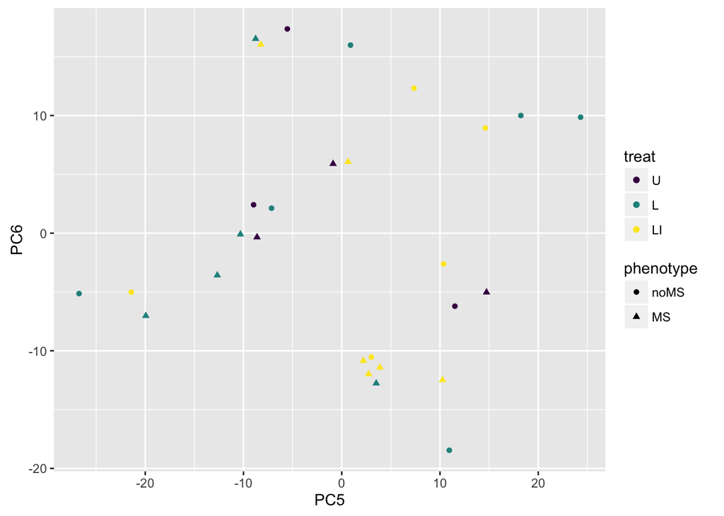

```r
> ggplot(comps, aes(PC5, PC6, color = treat, shape = phenotype)) + geom_point() +
+     scale_color_viridis(discrete = TRUE)
```

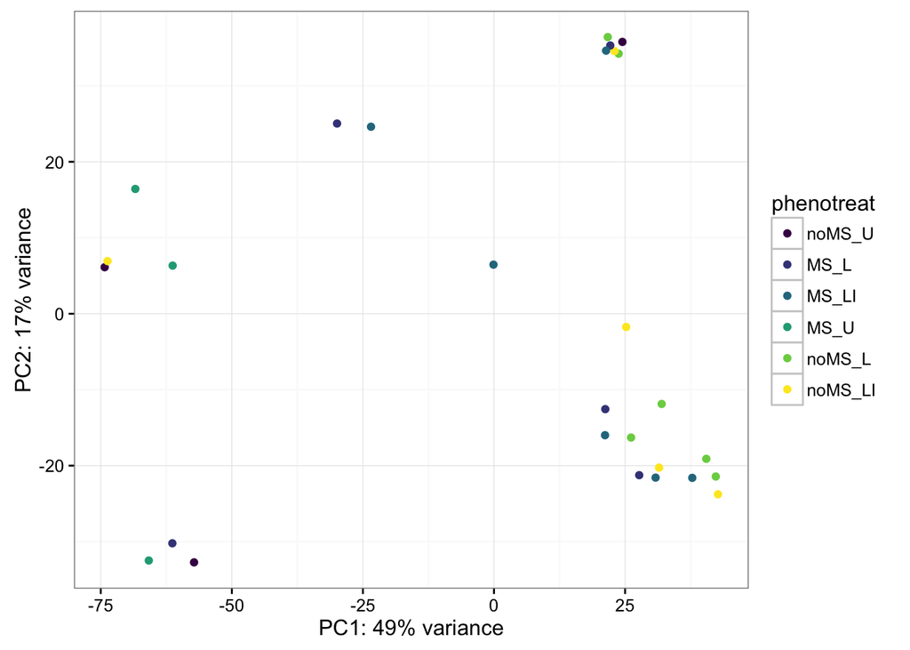

```r
> pca_plot(comps, 1, 2, "phenotreat") + scale_color_viridis(discrete = TRUE)
```

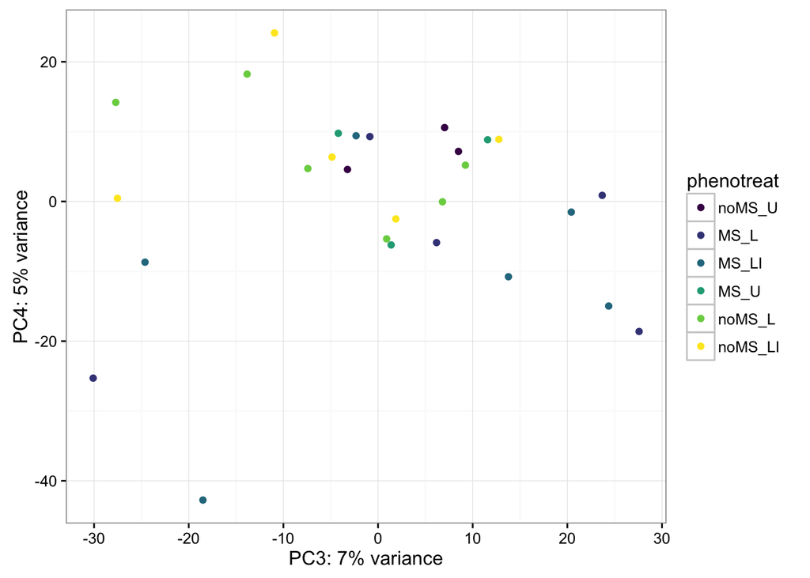

```r
> pca_plot(comps, 3, 4, "phenotreat") + scale_color_viridis(discrete = TRUE)
```

# Differential expresssion

I originally fit a model looking only within patients that are in the same `group`, since they are matched. This gave a lot of results that looked like spurious results; I think the reason for this is there are very few groups which have the full complement of patients, so we ended up fitting to just one or two samples.

I then dropped the group term, but this introduced spurious results from the different February and April sequencing. I added a term for month, and dropped the group, and that seems to give more sensible results.

Then we fit a term for `phenotype`, `treatment` and an interaction term between `phenotype` and `treatment` so we can look at the specific effects of each treatment. We fit this model:

$Y \sim month + treat + pheno + pheno:treat$

Which expands to:

$Y \sim \beta_0 + \beta_{1}x_{1} + \beta_{2}x_{2} + \beta_{3}x_{3} + \beta_{4}x_{1}x_{3} + \beta_{5}x_{2}x_{3}$

where

$x_{1} = \left\{ \begin{array}{ll} 1 & \text{treat is L} \\ 0 & \text{otherwise} \\ \end{array} \right.$

$x_{2} = \left\{ \begin{array}{ll} 1 & \text{treat is I} \\ 0 & \text{otherwise} \\ \end{array} \right.$

This gives the following meaning to the coefficients:

$\beta_{0} = \text{baseline expression in untreated, non MS cells}$

$\beta_{1} = \text{effect of L treatment on non-MS cells}$

$\beta_{2} = \text{effect of I treatment on non-MS cells}$

$\beta_{3} = \text{effect of MS on untreated cells}$

$\beta_{4} = \text{effect of L treatment on MS cells}$

$\beta_{5} = \text{effect of I treatment on MS cells}$

In the email this is what was asked for:

```
MS: (LPS vs. LPS+Il27);
HC: (LPS vs. LPS+IL27);
MS LPS vs. HS LPS;
MS LPS+IL27; HC LPS+IL27
And here, in addition, not plated (ex-vivo) MS vs. not plated HC
```

I’m not sure what the ex-vivo MS and not plated HC means in term of the project.

We can construct the other comparisons using the terms in the model.

Previous versions of this analysis used the raw count data matrix, but what was happening was the regression model was getting pulled by single samples that had huge outliers in some genes. In this version of the analysis, we Winsorize the count matrix before running the analysis. Winsorizing is just a fancy way of saying we replaced the highest value for each gene with the second highest value for outlier samples, to try to smooth out outliers.

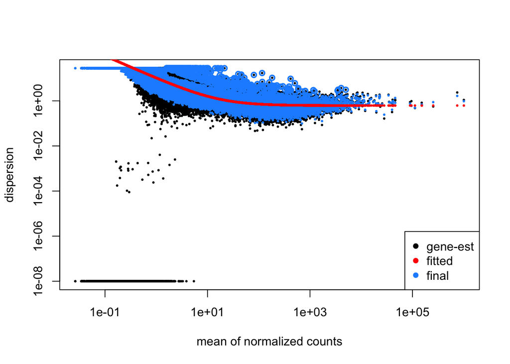

```r
> design = ~month + phenotype + treat + phenotype:treat
> library(scde)
> counts = winsorize.matrix(as.matrix(counts), 1)
> dds = DESeqDataSetFromMatrix(countData = counts, colData = metadata, design = design)
> dds = estimateSizeFactors(dds)
> dds = DESeq(dds)
> plotDispEsts(dds)
```

## MS LPS+IL27 vs HC LPS+IL27

Here we looking at the difference between the LPS+IL27 treated noMS samples and the LPS+IL27 treated MS samples. We are testing the differences between the $\beta_{5}$ and the $\beta_{2}$ coefficients above. Positive $log_{2}$ fold changes are higher in the LPS+IL27 treated MS samples than the LPS+IL27 noMS samples.

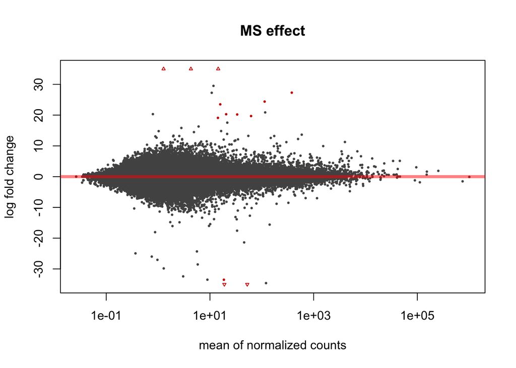

```r
> library(dplyr)
> li_ms_vs_hc = results(dds, contrast = list("phenotypeMS.treatLI", "treat_LI_vs_U"))
> plotMA(li_ms_vs_hc, ylim = c(-35, 35))
> title("MS effect")
```

```r
> li_ms_vs_hc = li_ms_vs_hc %>% as.data.frame() %>% add_rownames() %>% dplyr::rename(gene = rowname) %>%
+     left_join(symbols, by = c(gene = "ensembl_gene_id")) %>% arrange(padj)
> write.table(li_ms_vs_hc, file = "li_ms_vs_hc.csv", row.names = FALSE, col.names = TRUE,
+     quote = FALSE, sep = ",")
```

## MS LPS vs. HC LPS

Here we look at the difference between the LPS treated noMS samples and the LPS treated MS samples. We are testing the differences between the $\beta_{4}$ and $\beta_{1}$ coefficients above. Positive $log_{2}$ fold changes are higher in the LPS treated MS samples than the LPS treated HC samples.

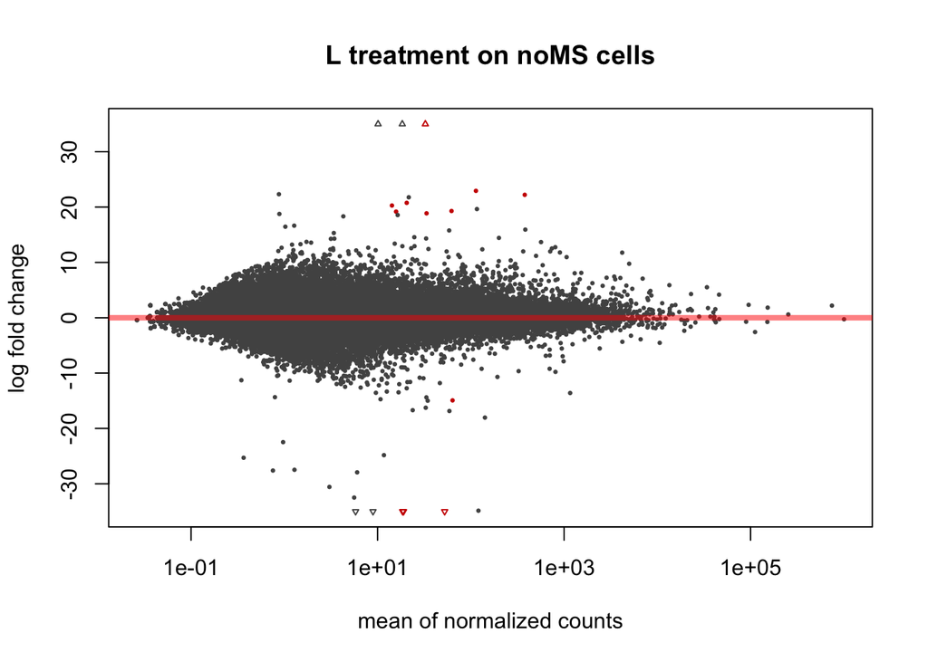

```r
> l_ms_vs_hc = results(dds, contrast = list("phenotypeMS.treatL", "treat_L_vs_U"))
> plotMA(l_ms_vs_hc, ylim = c(-35, 35))
> title("L treatment on noMS cells")
```

```r
> l_ms_vs_hc = l_ms_vs_hc %>% as.data.frame() %>% add_rownames() %>% dplyr::rename(gene = rowname) %>%
+     left_join(symbols, by = c(gene = "ensembl_gene_id")) %>% arrange(padj)
> write.table(l_ms_vs_hc, file = "l_ms_vs_hc.csv", row.names = FALSE, col.names = TRUE,
+     quote = FALSE, sep = ",")
```

## HC: (LPS vs LPS+IL27)

This is the effect of treating the noMS samples with LPS+IL27 compares to treating the noMS samples with LPS. We are testing the $\beta_{1}$ vs the $\beta_{2}$ coefficients above. Positive $log_{2}$ fold changes are higher in the noMS LPS+IL27 treated samples than the noMS LPS treated samples.

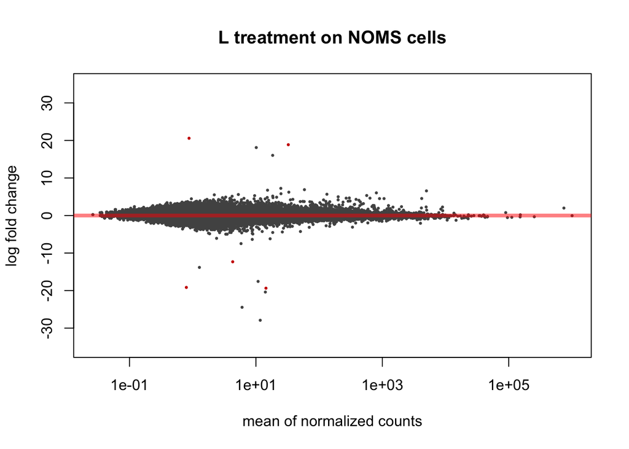

```r
> l_nomseffect = results(dds, contrast = list("treat_LI_vs_U", "treat_L_vs_U"))
> plotMA(l_nomseffect, ylim = c(-35, 35))
> title("L treatment on NOMS cells")
```

```r
> l_nomseffect = l_nomseffect %>% as.data.frame() %>% add_rownames() %>% dplyr::rename(gene = rowname) %>%
+     left_join(symbols, by = c(gene = "ensembl_gene_id")) %>% arrange(padj)
> write.table(l_nomseffect, file = "l_nomseffect.csv", row.names = FALSE, col.names = TRUE,
+     quote = FALSE, sep = ",")
```

## MS: (LPS vs. LPS+IL27)

This is the effect of treating the MS samples with LPS+IL27 compared to treating the MS samples with LPS We are testing the $\beta_{5}$ vs the $\beta_{4}$ coefficients above. Positive $log_{2}$ fold changes are higher in the MS LPS+IL27 treated samples than the MS LPS treated samples.

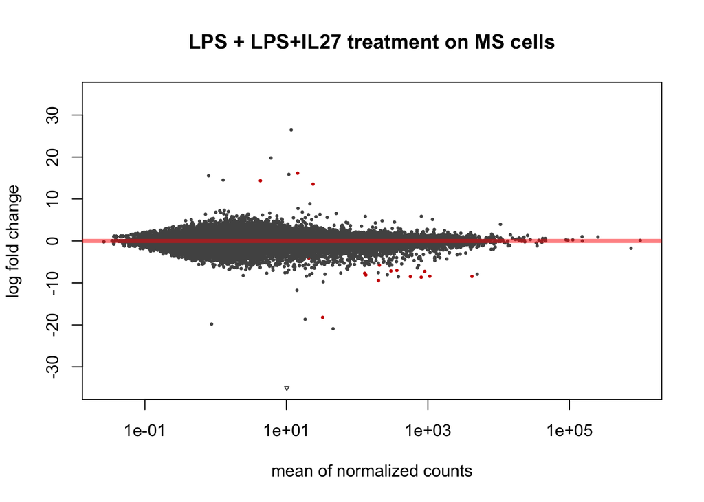

```r
> li_mseffect = results(dds, contrast = list("phenotypeMS.treatLI", "phenotypeMS.treatL"))
> plotMA(li_mseffect, ylim = c(-35, 35))
> title("LPS + LPS+IL27 treatment on MS cells")
```

```r
> li_mseffect = li_mseffect %>% as.data.frame() %>% add_rownames() %>% dplyr::rename(gene = rowname) %>%
+     left_join(symbols, by = c(gene = "ensembl_gene_id")) %>% arrange(padj)
> write.table(li_mseffect, file = "li_mseffect.csv", row.names = FALSE, col.names = TRUE,
+     quote = FALSE, sep = ",")
```

# Changes are not consistent

The top hit for the LI vs L in MS cells has a very large fold change, but when we look at the counts per gene for each sample, we can see it is due to a single outlier sample.

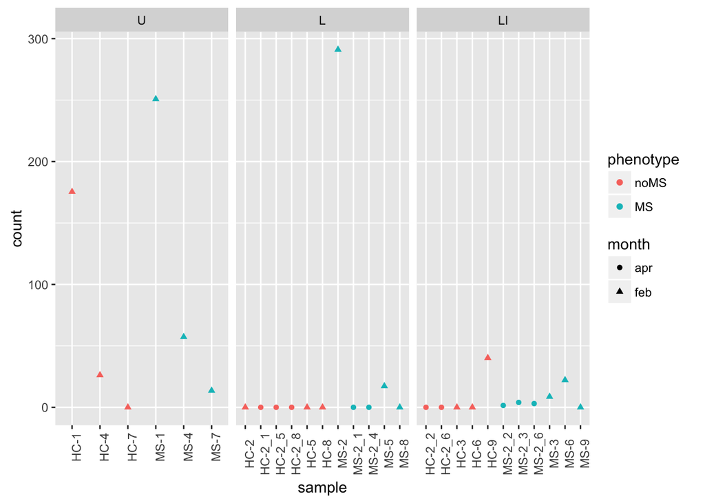

```r
> ncounts = counts(dds, normalized = TRUE) %>% as.data.frame() %>% add_rownames() %>%
+     dplyr::rename(gene = rowname) %>% tidyr::gather(sample, count, -gene) %>%
+     left_join(as.data.frame(colData(dds)), by = "sample")
> ggplot(subset(ncounts, gene == "ENSG00000182557"), aes(sample, count, color = phenotype,
+     shape = month)) + geom_point() + facet_wrap(~treat, scale = "free_x") +
+     theme(axis.text.x = element_text(angle = 90))
```

Filtering on baseMean > 50 doesn’t discard these fold changes, we still see single outlier samples driving the differences.

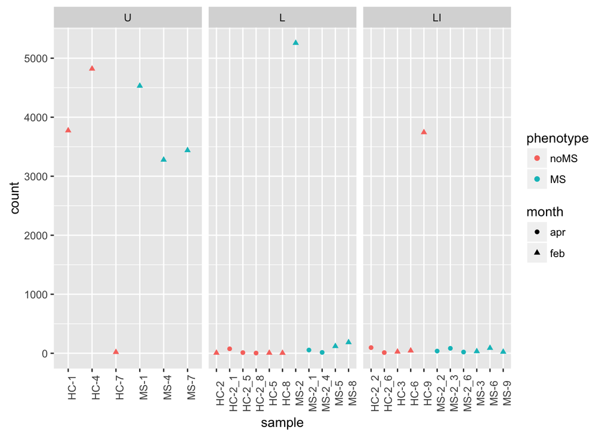

```r
> ggplot(subset(ncounts, gene == "ENSG00000106066"), aes(sample, count, color = phenotype,
+     shape = month)) + geom_point() + facet_wrap(~treat, scale = "free_x") +
+     theme(axis.text.x = element_text(angle = 90))
```

It isn’t just this one comparison. Here are the LPS+IL27 treated MS cells vs the LPS+IL27 treated HC cells. We can see several calls where one gene drives the difference.

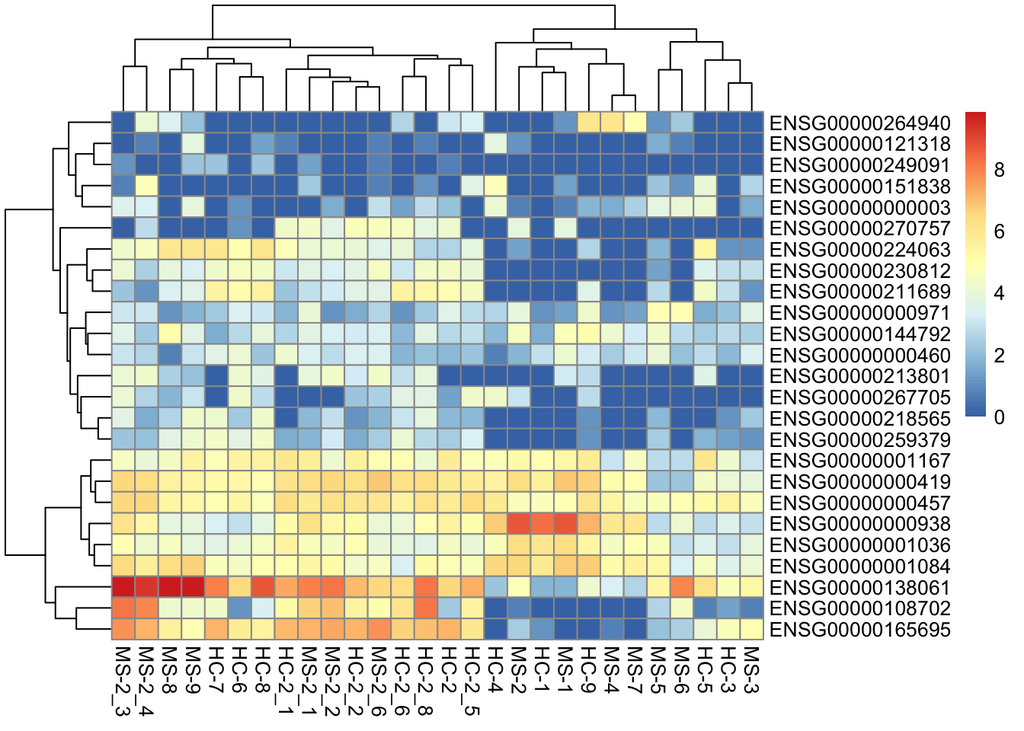

```r
> pheatmap(log(counts[head(li_ms_vs_hc, 25)$gene, ] + 1))
```

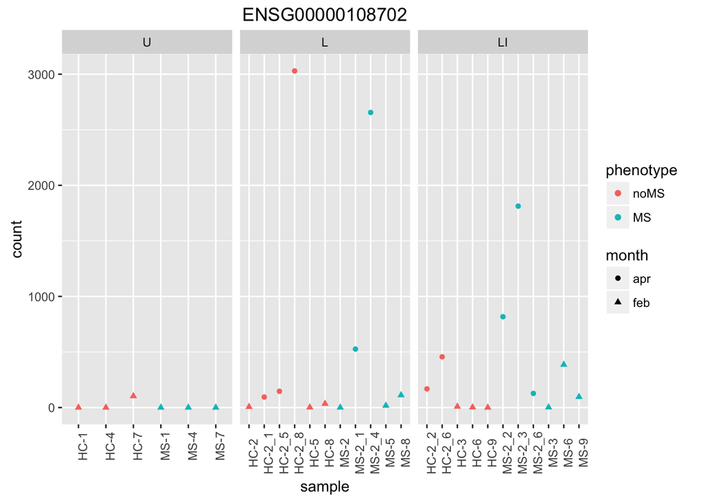

```r
> ggplot(subset(ncounts, gene == "ENSG00000108702"), aes(sample, count, color = phenotype,
+     shape = month)) + geom_point() + facet_wrap(~treat, scale = "free_x") +
+     theme(axis.text.x = element_text(angle = 90)) + ggtitle("ENSG00000108702")
```